# Insurance charges prediction model

Author

Diego Garza Valdez

## Loading data

```r
insurance_data <- read.csv("https://raw.githubusercontent.com/Diego150103/Bayesian_Project/refs/heads/main/insurance.csv")
```

## EDA

### Response

**Chargers**

```r
summary(insurance_data$charges)
```

```
   Min. 1st Qu.  Median    Mean 3rd Qu.    Max.
   1122    4740    9382   13270   16640   63770
```

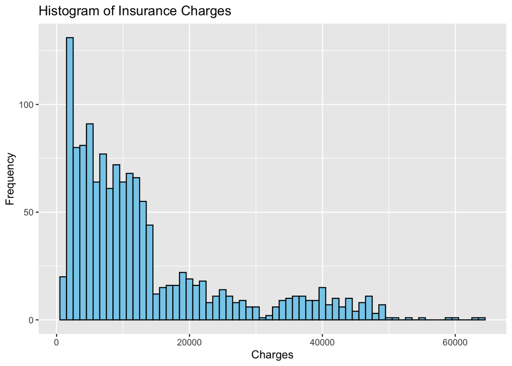

```r
ggplot(insurance_data, aes(x = charges)) +
  geom_histogram(binwidth = 1000, fill = "skyblue", color = "black") +
  labs(title = "Histogram of Insurance Charges", x = "Charges", y = "Frequency")
```

### Predictors

**Age**

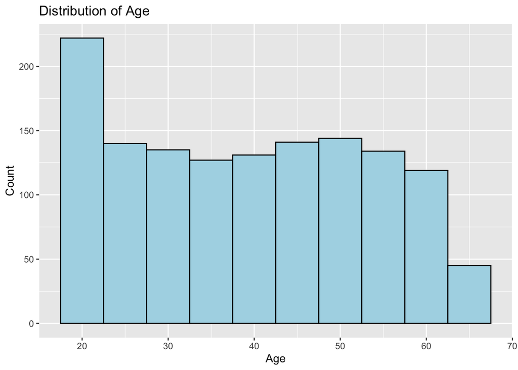

```r
ggplot(insurance_data, aes(x = age)) +
  geom_histogram(binwidth = 5, fill = "lightblue", color = "black") +
  labs(title = "Distribution of Age", x = "Age", y = "Count")
```

**BMI**

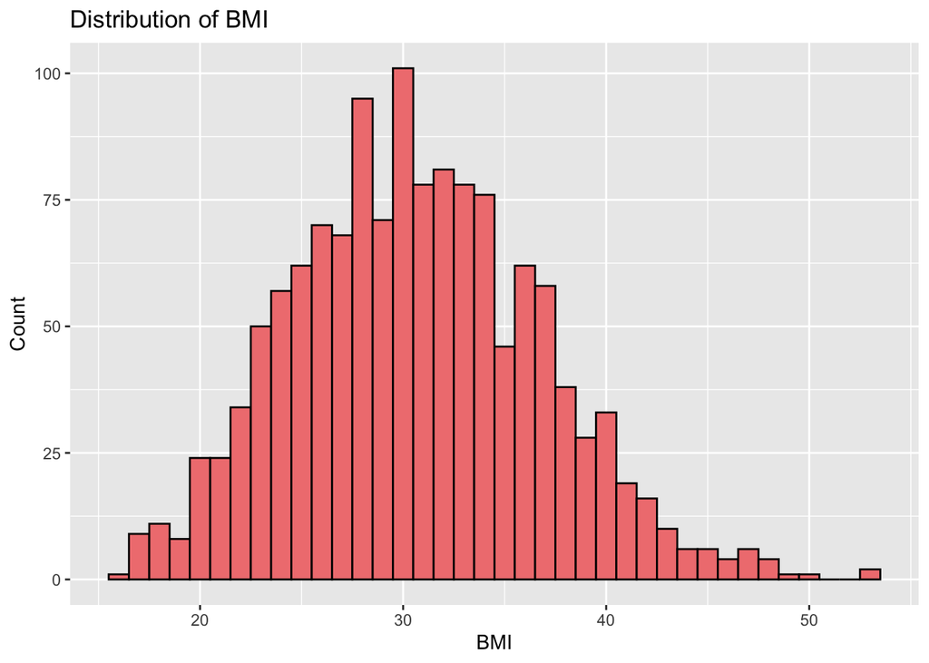

```r
ggplot(insurance_data, aes(x = bmi)) +
  geom_histogram(binwidth = 1, fill = "lightcoral", color = "black") +
  labs(title = "Distribution of BMI", x = "BMI", y = "Count")
```

**Number of Children**

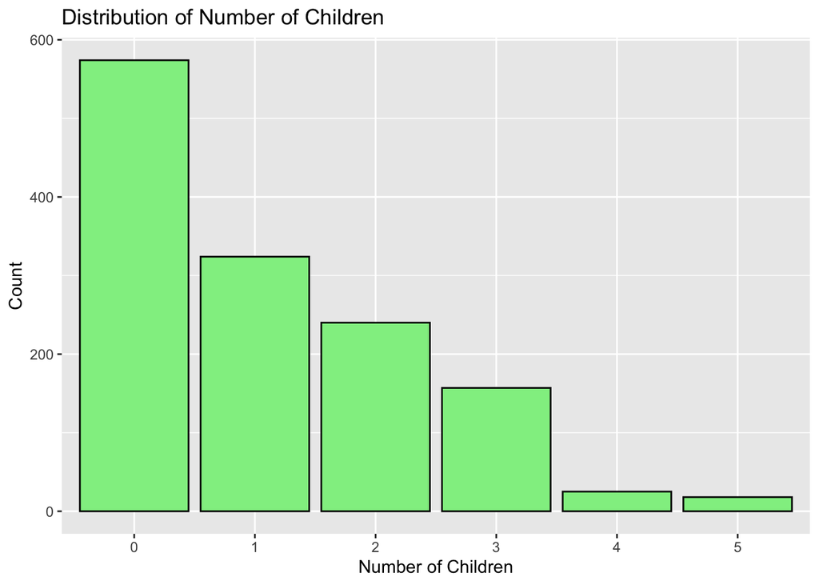

```r
ggplot(insurance_data, aes(x = factor(children))) +
  geom_bar(fill = "lightgreen", color = "black") +
  labs(title = "Distribution of Number of Children", x = "Number of Children", y = "Count")
```

**Sex**

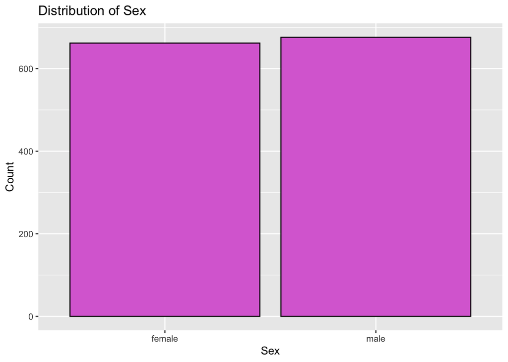

```r
ggplot(insurance_data, aes(x = sex)) +
  geom_bar(fill = "orchid", color = "black") +
  labs(title = "Distribution of Sex", x = "Sex", y = "Count")
```

**Smoker**

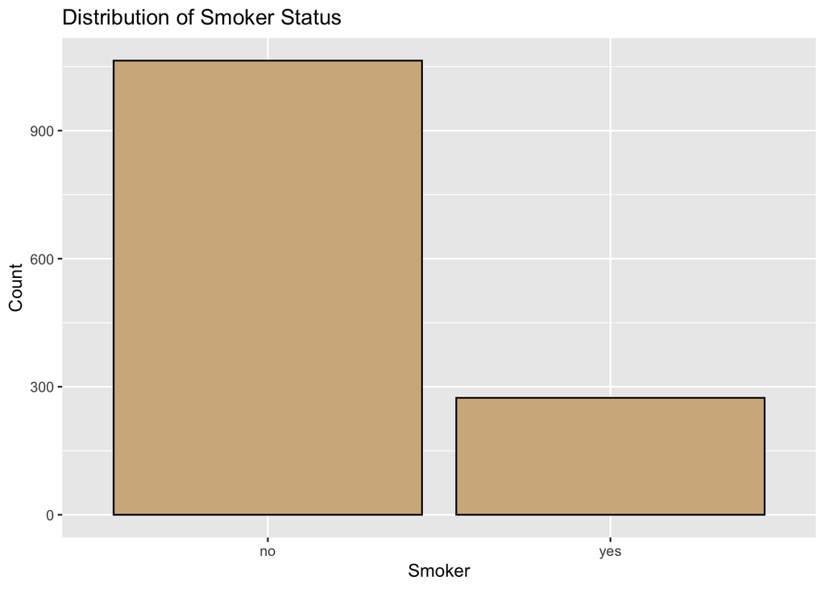

```r
ggplot(insurance_data, aes(x = smoker)) +
  geom_bar(fill = "tan", color = "black") +
  labs(title = "Distribution of Smoker Status", x = "Smoker", y = "Count")
```

**Region**

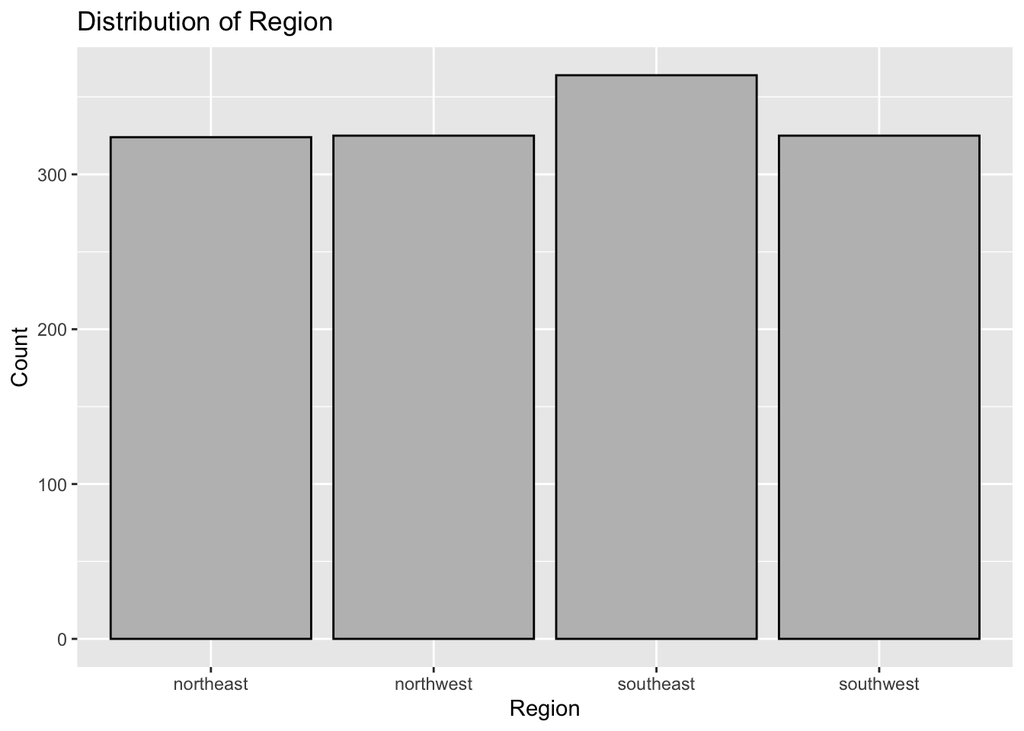

```r
ggplot(insurance_data, aes(x = region)) +
  geom_bar(fill = "gray", color = "black") +
  labs(title = "Distribution of Region", x = "Region", y = "Count")
```

## Model Creation

```r
insurance_data$sex_male   <- as.integer(insurance_data$sex   == "male")
insurance_data$smoker_yes <- as.integer(insurance_data$smoker == "yes")
insurance_data$region_id <- as.integer(factor(insurance_data$region,
                                              levels = c("northeast","northwest","southeast","southwest")))

N <- nrow(insurance_data)
y <- insurance_data$charges
```

## Model 1: Intercept-Only

**Data model**
$$y_i \sim \operatorname{LogNormal}(\mu,\;\sigma^2)
\quad i = 1,\dots,N$$

**Priors**
$$\mu \;\sim\; \mathcal{N}(0,\;100^2),
\qquad
\sigma^2 \;\sim\; \operatorname{InvGamma}(0.01,\,0.01)$$

```r
model1_code = "
data {
  int<lower=1> N;
  vector<lower=0>[N] y;
}
parameters {
  real mu;
  real<lower=0> sigmasq;
}
transformed parameters {
  real<lower=0> sigma = sqrt(sigmasq);
}
model {
  mu       ~ normal(0, 100^2);
  sigmasq  ~ inv_gamma(.01, .01);
  y        ~ lognormal(mu, sigma);
}
generated quantities {
  vector[N] yrep;
  real log_lik[N];
  for (j in 1:N) {
    yrep[j]    = lognormal_rng(mu, sigma);
    log_lik[j] = lognormal_lpdf(y[j] | mu, sigma);
  }
}
"
```

```r
model1_data = list(N = N, y = y)

if (!file.exists("model1_mod.rda")) {
  model1_mod <- stan_model(model_code = model1_code)
  save(model1_mod, file = "model1_mod.rda", compress = "xz")
} else {
  load("model1_mod.rda")
}

fit1 <- sampling(model1_mod,
                 data = model1_data,
                 iter=10000, warmup=5000, seed = 101, chains = 4, refresh = 0)
```

### Convergence check

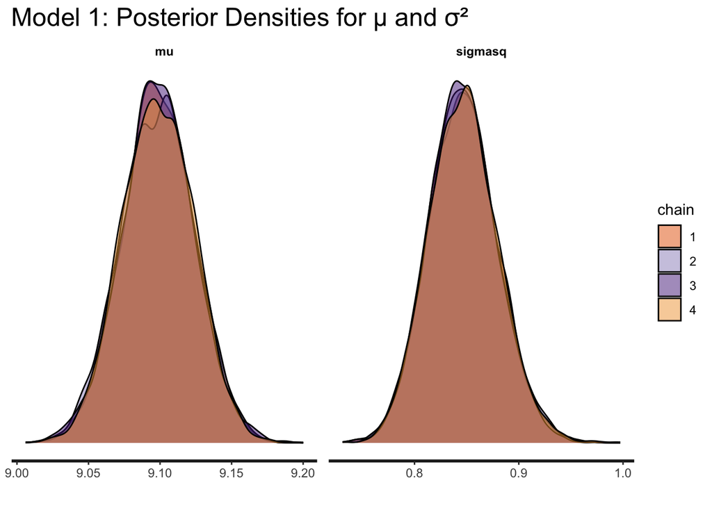

```r
stan_dens(fit1,
          pars = c("mu", "sigmasq"),
          separate_chains = TRUE) +
  ggtitle("Model 1: Posterior Densities for μ and σ²")
```

## Model 2: + Age & BMI

**Linear predictor**
$$\eta_i = \beta_0 + \beta_{\text{age}}\,\text{age}_i
+ \beta_{\text{bmi}}\,\text{bmi}_i$$

**Data model**
$$y_i \sim \operatorname{LogNormal}(\eta_i,\;\sigma^2)$$

**Priors**
$$\beta_0,\;\beta_{\text{age}},\;\beta_{\text{bmi}}
\;\sim\; \mathcal{N}(0,\;100^2),
\quad
\sigma^2 \;\sim\; \operatorname{InvGamma}(0.01,\,0.01)$$

```r
model2_code = "
data {
  int<lower=1> N;
  vector<lower=0>[N] y;
  vector[N] age;
  vector[N] bmi;
}
parameters {
  real beta0;
  real beta_age;
  real beta_bmi;
  real<lower=0> sigmasq;
}
transformed parameters {
  real<lower=0> sigma = sqrt(sigmasq);
}
model {
  beta0    ~ normal(0, 100^2);
  beta_age ~ normal(0, 100^2);
  beta_bmi ~ normal(0, 100^2);
  sigmasq  ~ inv_gamma(.01, .01);
  for (n in 1:N) {
    real mu_n = beta0 + beta_age * age[n] + beta_bmi * bmi[n];
    y[n]     ~ lognormal(mu_n, sigma);
  }
}
generated quantities {
  vector[N] yrep;
  real log_lik[N];
  for (n in 1:N) {
    real mu_n    = beta0 + beta_age * age[n] + beta_bmi * bmi[n];
    yrep[n]      = lognormal_rng(mu_n, sigma);
    log_lik[n]   = lognormal_lpdf(y[n] | mu_n, sigma);
  }
}
"
```

```r
model2_data = list(
  N   = N,
  y   = y,
  age = insurance_data$age,
  bmi = insurance_data$bmi
)

if (!file.exists("model2_mod.rda")) {
  model2_mod <- stan_model(model_code = model2_code)
  save(model2_mod, file = "model2_mod.rda", compress = "xz")
} else {
  load("model2_mod.rda")
}

fit2 <- sampling(model2_mod,
                 data = model2_data,
                iter=10000, warmup=5000, seed = 101, chains = 4, refresh = 0)
```

### Convergence check

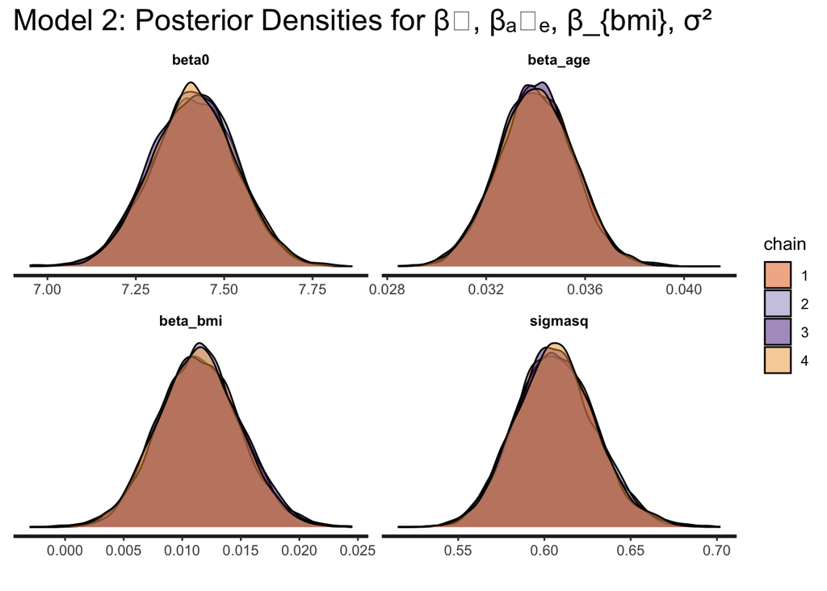

```r
stan_dens(fit2,
          pars = c("beta0", "beta_age", "beta_bmi", "sigmasq"),
          separate_chains = TRUE) +
  ggtitle("Model 2: Posterior Densities for β₀, βₐ₉ₑ, β_{bmi}, σ²")
```

## Model 3: + Children, Sex, Smoker, Region

**Linear predictor**
$$\begin{aligned}
\eta_i = \beta_0
&+ \beta_{\text{age}}\,\text{age}_i
+ \beta_{\text{bmi}}\,\text{bmi}_i
+ \beta_{\text{children}}\,\text{children}_i \\
&+ \beta_{\text{sex}}\,\text{sex}_i
+ \beta_{\text{smoker}}\,\text{smoker}_i
+ \beta_{\text{SE}}\,\text{region_SE}_i
+ \beta_{\text{SW}}\,\text{region_SW}_i
+ \beta_{\text{NW}}\,\text{region_NW}_i
\end{aligned}$$

**Data model**
$$y_i \sim \operatorname{LogNormal}(\eta_i,\;\sigma^2)$$

**Priors**
$$\beta_j \;\sim\; \mathcal{N}(0,\;100^2)
\quad\forall j,\qquad
\sigma^2 \;\sim\; \operatorname{InvGamma}(0.01,\,0.01)$$

```r
model3_code = "
data {
  int<lower=1>       N;
  vector<lower=0>[N] y;
  vector[N]          age;
  vector[N]          bmi;
  int<lower=0>       children[N];
  vector[N]          sex;
  vector[N]          smoker;
  vector[N]          region_SE;
  vector[N]          region_SW;
  vector[N]          region_NW;
}
parameters {
  real              beta0;
  real              beta_age;
  real              beta_bmi;
  real              beta_children;
  real              beta_sex;
  real              beta_smoker;
  real              beta_se;
  real              beta_sw;
  real              beta_nw;
  real<lower=0>      sigmasq;
}
transformed parameters {
  real<lower=0> sigma = sqrt(sigmasq);
}
model {
  beta0         ~ normal(0, 100^2);
  beta_age      ~ normal(0, 100^2);
  beta_bmi      ~ normal(0, 100^2);
  beta_children ~ normal(0, 100^2);
  beta_sex      ~ normal(0, 100^2);
  beta_smoker   ~ normal(0, 100^2);
  beta_se       ~ normal(0, 100^2);
  beta_sw       ~ normal(0, 100^2);
  beta_nw       ~ normal(0, 100^2);
  sigmasq       ~ inv_gamma(.01, .01);
  for (n in 1:N) {
    real mu_n = beta0
      + beta_age      * age[n]
      + beta_bmi      * bmi[n]
      + beta_children * children[n]
      + beta_sex      * sex[n]
      + beta_smoker   * smoker[n]
      + beta_se       * region_SE[n]
      + beta_sw       * region_SW[n]
      + beta_nw       * region_NW[n];
    y[n] ~ lognormal(mu_n, sigma);
  }
}
generated quantities {
  vector[N] yrep;
  real      log_lik[N];
  for (n in 1:N) {
    real mu_n   = beta0
      + beta_age      * age[n]
      + beta_bmi      * bmi[n]
      + beta_children * children[n]
      + beta_sex      * sex[n]
      + beta_smoker   * smoker[n]
      + beta_se       * region_SE[n]
      + beta_sw       * region_SW[n]
      + beta_nw       * region_NW[n];
    yrep[n]    = lognormal_rng(mu_n, sigma);
    log_lik[n] = lognormal_lpdf(y[n] | mu_n, sigma);
  }
}
"
```

```r
model3_data = list(
  N         = N,
  y         = y,
  age       = insurance_data$age,
  bmi       = insurance_data$bmi,
  children  = insurance_data$children,
  sex       = insurance_data$sex_male,
  smoker    = insurance_data$smoker_yes,
  region_SE = as.integer(insurance_data$region=="southeast"),
  region_SW = as.integer(insurance_data$region=="southwest"),
  region_NW = as.integer(insurance_data$region=="northwest")
)

if (!file.exists("model3_mod.rda")) {
  model3_mod <- stan_model(model_code = model3_code)
  save(model3_mod, file = "model3_mod.rda", compress = "xz")
} else {
  load("model3_mod.rda")
}

fit3 <- sampling(model3_mod,
                 data = model3_data,
                 iter=10000, warmup=5000, seed = 101, chains = 4, refresh = 0)
```

### Convergence check

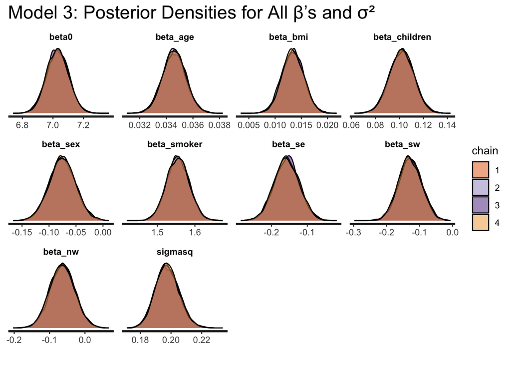

```r
stan_dens(fit3,
          pars = c("beta0",
                   "beta_age", "beta_bmi",
                   "beta_children", "beta_sex", "beta_smoker",
                   "beta_se", "beta_sw", "beta_nw",
                   "sigmasq"),
          separate_chains = TRUE) +
  ggtitle("Model 3: Posterior Densities for All β’s and σ²")
```

## Model 4: + Smoker × Age Interaction

**Linear predictor**
$$\begin{aligned}
\eta_i = \beta_0
&+ \beta_{\text{age}}\,\text{age}_i
+ \beta_{\text{bmi}}\,\text{bmi}_i
+ \beta_{\text{children}}\,\text{children}_i \\
&+ \beta_{\text{sex}}\,\text{sex}_i
+ \beta_{\text{smoker}}\,\text{smoker}_i
+ \beta_{\text{smoke×age}}\,(\text{smoker}_i \times \text{age}_i) \\
&+ \beta_{\text{SE}}\,\text{region_SE}_i
+ \beta_{\text{SW}}\,\text{region_SW}_i
+ \beta_{\text{NW}}\,\text{region_NW}_i
\end{aligned}$$

**Data model**
$$y_i \sim \operatorname{LogNormal}(\eta_i,\;\sigma^2)$$

**Priors**
$$\beta_j \;\sim\; \mathcal{N}(0,\;100^2)
\quad\forall j,\qquad
\sigma^2 \;\sim\; \operatorname{InvGamma}(0.01,\,0.01)$$

```r
model4_code = "
data {
  int<lower=1>       N;
  vector<lower=0>[N] y;
  vector[N]          age;
  vector[N]          bmi;
  int<lower=0>       children[N];
  vector[N]          sex;
  vector[N]          smoker;
  vector[N]          smoke_age;
  vector[N]          region_SE;
  vector[N]          region_SW;
  vector[N]          region_NW;
}
parameters {
  real beta0;
  real beta_age;
  real beta_bmi;
  real beta_children;
  real beta_sex;
  real beta_smoker;
  real beta_smoke_age;
  real beta_se;
  real beta_sw;
  real beta_nw;
  real<lower=0> sigmasq;
}
transformed parameters {
  real<lower=0> sigma = sqrt(sigmasq);
}
model {
  beta0          ~ normal(0, 100^2);
  beta_age       ~ normal(0, 100^2);
  beta_bmi       ~ normal(0, 100^2);
  beta_children  ~ normal(0, 100^2);
  beta_sex       ~ normal(0, 100^2);
  beta_smoker    ~ normal(0, 100^2);
  beta_smoke_age ~ normal(0, 100^2);
  beta_se        ~ normal(0, 100^2);
  beta_sw        ~ normal(0, 100^2);
  beta_nw        ~ normal(0, 100^2);
  sigmasq        ~ inv_gamma(0.01, 0.01);
  for (n in 1:N) {
    real mu_n = beta0
      + beta_age       * age[n]
      + beta_bmi       * bmi[n]
      + beta_children  * children[n]
      + beta_sex       * sex[n]
      + beta_smoker    * smoker[n]
      + beta_smoke_age * smoke_age[n]
      + beta_se        * region_SE[n]
      + beta_sw        * region_SW[n]
      + beta_nw        * region_NW[n];
    y[n] ~ lognormal(mu_n, sigma);
  }
}
generated quantities {
  vector[N] yrep;
  real      log_lik[N];
  for (n in 1:N) {
    real mu_n     = beta0
      + beta_age       * age[n]
      + beta_bmi       * bmi[n]
      + beta_children  * children[n]
      + beta_sex       * sex[n]
      + beta_smoker    * smoker[n]
      + beta_smoke_age * smoke_age[n]
      + beta_se        * region_SE[n]
      + beta_sw        * region_SW[n]
      + beta_nw        * region_NW[n];
    yrep[n]      = lognormal_rng(mu_n, sigma);
    log_lik[n]   = lognormal_lpdf(y[n] | mu_n, sigma);
  }
}
"
```

```r
model4_data = c(
  model3_data,
  list(smoke_age = insurance_data$age * insurance_data$smoker_yes)
)

if (!file.exists("model4_mod.rda")) {
  model4_mod <- stan_model(model_code = model4_code)
  save(model4_mod, file = "model4_mod.rda", compress = "xz")
} else {
  load("model4_mod.rda")
}

fit4 <- sampling(model4_mod,
                 data = model4_data,
                 iter=10000, warmup=5000, seed = 101, chains = 4, refresh = 0)
```

### Convergence check

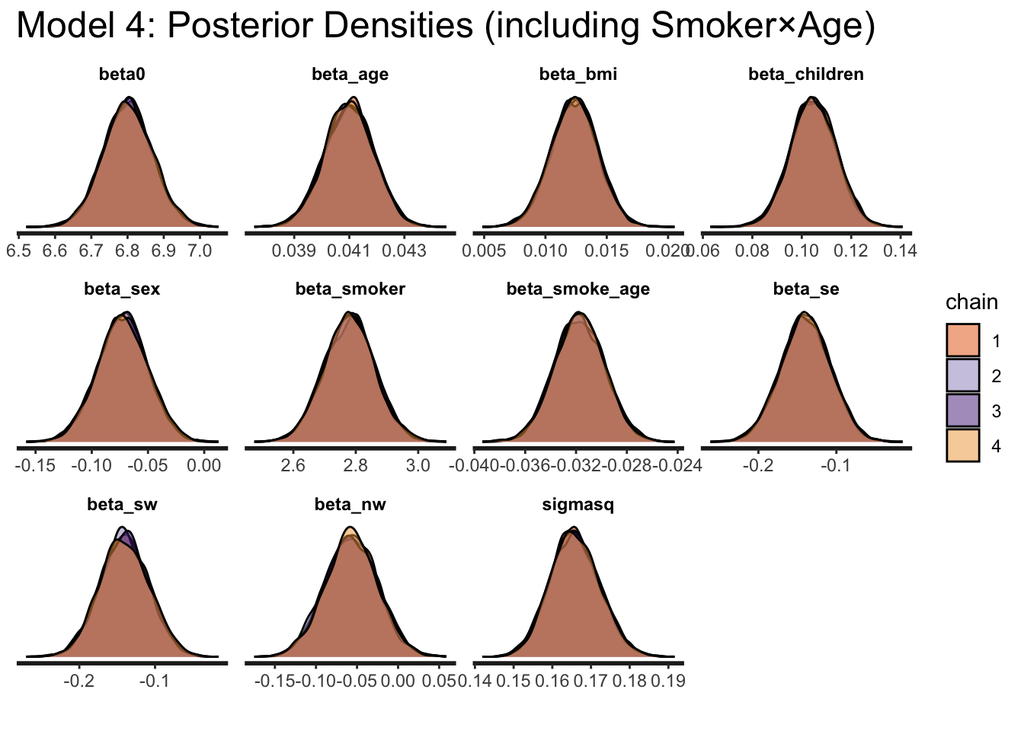

```r
stan_dens(fit4,
          pars = c("beta0",
                   "beta_age", "beta_bmi",
                   "beta_children", "beta_sex", "beta_smoker",
                   "beta_smoke_age",
                   "beta_se", "beta_sw", "beta_nw",
                   "sigmasq"),
          separate_chains = TRUE) +
  ggtitle("Model 4: Posterior Densities (including Smoker×Age)")
```

## Model 5: Varying Intercepts by Region

Let $r_i$ be the region index of observation $i$, with $r_i\in\{1,\dots,R\}$. Introduce a separate intercept for each region.

**Hierarchical predictor**
$$\eta_i = \beta_0
+ a_{r_i}
+ \beta_{\text{age}}\,\text{age}_i
+ \beta_{\text{bmi}}\,\text{bmi}_i
+ \beta_{\text{children}}\,\text{children}_i
+ \beta_{\text{sex}}\,\text{sex}_i
+ \beta_{\text{smoker}}\,\text{smoker}_i$$

**Data model**
$$y_i \sim \operatorname{LogNormal}(\eta_i,\;\sigma^2)$$

**Priors**
$$\begin{aligned}
\beta_j &\sim \mathcal{N}(0,\;100^2)\quad\forall j,\\
a_r &\sim \mathcal{N}(0,\;\tau^2)\quad r=1,\dots,R,\\
\tau^2 &\sim \operatorname{InvGamma}(0.01,\,0.01),\\
\sigma^2 &\sim \operatorname{InvGamma}(0.01,\,0.01).
\end{aligned}$$

```r
model5_code = "
data {
  int<lower=1>       N;
  int<lower=1>       R;
  int<lower=1,upper=R> region_id[N];
  vector<lower=0>[N] y;
  vector[N]          age;
  vector[N]          bmi;
  int<lower=0>       children[N];
  vector[N]          sex;
  vector[N]          smoker;
}
parameters {
  real              beta0;
  vector[R]         a_region;
  real<lower=0>     sigmasq_region;
  real              beta_age;
  real              beta_bmi;
  real              beta_children;
  real              beta_sex;
  real              beta_smoker;
  real<lower=0>     sigmasq;
}
transformed parameters {
  real<lower=0> sigma = sqrt(sigmasq);
  real<lower=0> sigma_region = sqrt(sigmasq_region);
}
model {
  beta0         ~ normal(0, 100^2);
  beta_age      ~ normal(0, 100^2);
  beta_bmi      ~ normal(0, 100^2);
  beta_children ~ normal(0, 100^2);
  beta_sex      ~ normal(0, 100^2);
  beta_smoker   ~ normal(0, 100^2);
  a_region      ~ normal(0, sigma_region);
  sigmasq_region ~ inv_gamma(0.01, 0.01);
  sigmasq       ~ inv_gamma(0.01, 0.01);
  for (n in 1:N) {
    real mu_n = beta0
      + a_region[region_id[n]]
      + beta_age      * age[n]
      + beta_bmi      * bmi[n]
      + beta_children * children[n]
      + beta_sex      * sex[n]
      + beta_smoker   * smoker[n];
    y[n] ~ lognormal(mu_n, sigma);
  }
}
generated quantities {
  vector[N] yrep;
  real      log_lik[N];
  for (n in 1:N) {
    real mu_n    = beta0
      + a_region[region_id[n]]
      + beta_age      * age[n]
      + beta_bmi      * bmi[n]
      + beta_children * children[n]
      + beta_sex      * sex[n]
      + beta_smoker   * smoker[n];
    yrep[n]     = lognormal_rng(mu_n, sigma);
    log_lik[n]  = lognormal_lpdf(y[n] | mu_n, sigma);
  }
}
"
```

```r
model5_data = list(
  N         = N,
  R         = length(unique(insurance_data$region_id)),
  region_id = insurance_data$region_id,
  y         = y,
  age       = insurance_data$age,
  bmi       = insurance_data$bmi,
  children  = insurance_data$children,
  sex       = insurance_data$sex_male,
  smoker    = insurance_data$smoker_yes
)

if (!file.exists("model5_mod.rda")) {
  model5_mod <- stan_model(model_code = model5_code)
  save(model5_mod, file = "model5_mod.rda", compress = "xz")
} else {
  load("model5_mod.rda")
}

load("model5_mod.rda")
fit5 <- sampling(model5_mod,
                 data = model5_data,
                 iter=10000, warmup=5000, seed = 101, chains = 4, refresh = 0)
```

### Convergence check

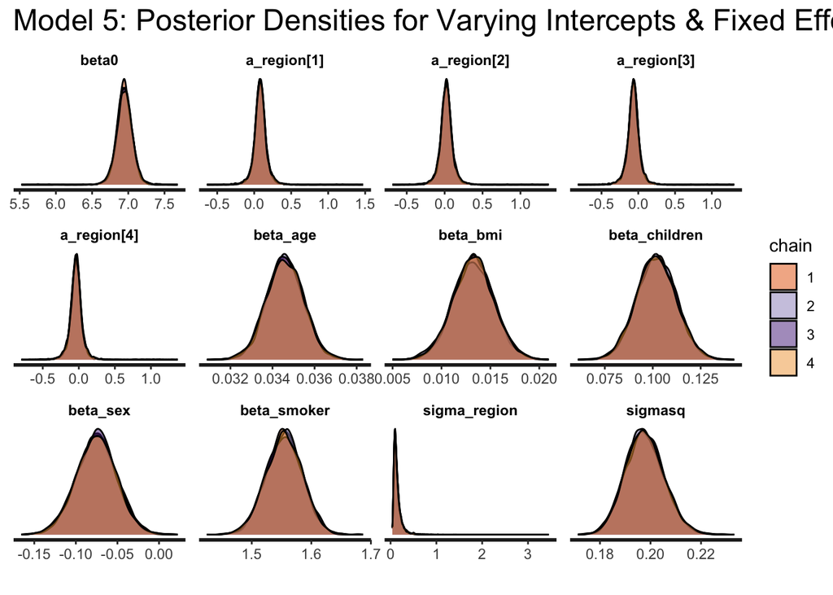

```r
stan_dens(fit5,
          pars = c("beta0",
                   "a_region[1]", "a_region[2]", "a_region[3]", "a_region[4]",
                   "beta_age", "beta_bmi", "beta_children",
                   "beta_sex", "beta_smoker",
                   "sigma_region", "sigmasq"),
          separate_chains = TRUE) +
  ggtitle("Model 5: Posterior Densities for Varying Intercepts & Fixed Effects")
```

## Selecting best model

```r
# Model 1
log_lik1 <- extract_log_lik(fit1, parameter_name = "log_lik")
waic1    <- waic(log_lik1)
loo1     <- loo(log_lik1)

# Model 2
log_lik2 <- extract_log_lik(fit2, parameter_name = "log_lik")
waic2    <- waic(log_lik2)
loo2     <- loo(log_lik2)

# Model 3
log_lik3 <- extract_log_lik(fit3, parameter_name = "log_lik")
waic3    <- waic(log_lik3)
loo3     <- loo(log_lik3)

# Model 4
log_lik4 <- extract_log_lik(fit4, parameter_name = "log_lik")
waic4    <- waic(log_lik4)
loo4     <- loo(log_lik4)

# Model 5
log_lik5 <- extract_log_lik(fit5, parameter_name = "log_lik")
waic5    <- waic(log_lik5)
loo5     <- loo(log_lik5)
```

```r
# Put your waic & loo objects into lists
waic_list <- list(
  Model1 = waic1,
  Model2 = waic2,
  Model3 = waic3,
  Model4 = waic4,
  Model5 = waic5
)

loo_list <- list(
  Model1 = loo1,
  Model2 = loo2,
  Model3 = loo3,
  Model4 = loo4,
  Model5 = loo5
)


comparison_df <- data.frame(
  Model = names(waic_list),
  WAIC  = sapply(waic_list, function(w) w$estimates["waic","Estimate"]),
  LOOIC = sapply(loo_list,  function(l) l$estimates["looic","Estimate"])
)


comparison_df <- comparison_df[order(comparison_df$WAIC), ]
comparison_df
```

```
        Model     WAIC    LOOIC
Model4 Model4 25755.30 25755.31
Model5 Model5 25987.40 25987.41
Model3 Model3 25987.58 25987.60
Model2 Model2 27480.34 27480.34
Model1 Model1 27923.28 27923.29
```

```r
loo_comp <- loo_compare(loo1, loo2, loo3, loo4, loo5)
loo_comp
```

```
       elpd_diff se_diff
model4     0.0       0.0
model5  -116.0      18.9
model3  -116.1      18.9
model2  -862.5      56.7
model1 -1084.0      60.9
```

Model 4 is the best one.

## Check model fit

### Density

```r
obs <- y
```

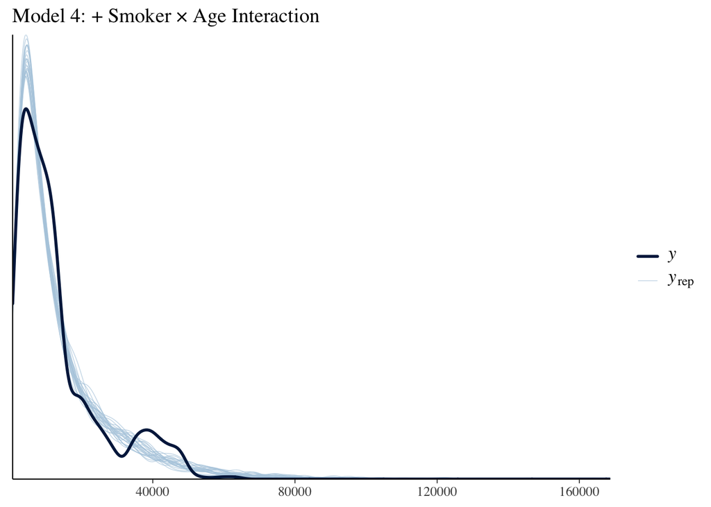

```r
# Model 4
yrep4 <- extract(fit4, "yrep")$yrep
ppc_dens_overlay(obs, yrep4[1:25, ]) +
  ggtitle("Model 4: + Smoker × Age Interaction")
```

### Histogram

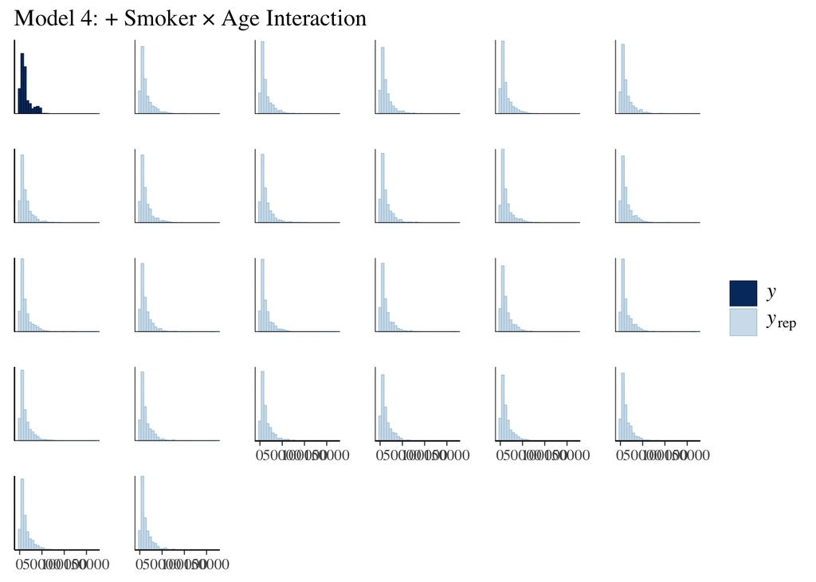

```r
# Model 4
yrep4 <- extract(fit4, "yrep")$yrep
ppc_hist(obs, yrep4[1:25, ]) +
  ggtitle("Model 4: + Smoker × Age Interaction")
```

## **Best model parameters**

```r
fit4_summary <- summary(fit4)$summary

params4 <- c(
  "beta0",
  "beta_age",
  "beta_bmi",
  "beta_children",
  "beta_sex",
  "beta_smoker",
  "beta_smoke_age",
  "beta_se",
  "beta_sw",
  "beta_nw",
  "sigmasq"
)

post_table4 <- fit4_summary[params4, c("mean", "sd", "2.5%", "97.5%")]

round(post_table4,3)
```

```
                 mean    sd   2.5%  97.5%
beta0           6.801 0.068  6.668  6.937
beta_age        0.041 0.001  0.039  0.043
beta_bmi        0.012 0.002  0.009  0.016
beta_children   0.105 0.009  0.087  0.123
beta_sex       -0.073 0.022 -0.117 -0.029
beta_smoker     2.780 0.082  2.621  2.941
beta_smoke_age -0.032 0.002 -0.036 -0.028
beta_se        -0.139 0.032 -0.203 -0.077
beta_sw        -0.140 0.033 -0.204 -0.077
beta_nw        -0.057 0.032 -0.120  0.006
sigmasq         0.166 0.006  0.154  0.179
```

| Parameter | mean | sd | 2.5% | 97.5% |
| --- | --- | --- | --- | --- |
| $\beta_{0}$ | 6.801 | 0.068 | 6.668 | 6.937 |
| $\beta_{age}$ | 0.041 | 0.001 | 0.039 | 0.043 |
| $\beta_{bmi}$ | 0.012 | 0.002 | 0.009 | 0.016 |
| $\beta_{children}$ | 0.105 | 0.009 | 0.087 | 0.123 |
| $\beta_{sex}$ | −0.073 | 0.022 | −0.117 | −0.029 |
| $\beta_{smoker}$ | 2.780 | 0.082 | 2.621 | 2.941 |
| $\beta_{smoke \times age}$ | −0.032 | 0.002 | −0.036 | −0.028 |
| $\beta_{SE}$ | −0.139 | 0.032 | −0.203 | −0.077 |
| $\beta_{SW}$ | −0.140 | 0.033 | −0.204 | −0.077 |
| $\beta_{NW}$ | −0.057 | 0.032 | −0.120 | 0.006 |
| $\sigma^2$ | 0.166 | 0.006 | 0.154 | 0.179 |

### Interpretation

- **Starting point** $\beta_{0} \approx 6.801\ [6.668,\ 6.937]$;  
  On the log scale, the baseline prediction is 6.801 for someone age 0, BMI 0, no children, female non‐smoker in the Northeast. Exponentiating gives $\exp(6.801)\approx\$901$, which is the charge we’d predict before adding any other effects.
- **Age** $\beta_{age} \approx 0.041\ [0.039,\ 0.043]$;  
  Comparing two people who are identical in BMI, number of children, sex, smoking status, and region, the one who is one year older has a charge about $\exp(0.041)\approx1.042$ times as large. That is, **4.2% higher**.
- **BMI** $\beta_{bmi} \approx 0.012\ [0.009,\ 0.016]$;  
  Comparing two people of the same age, children, sex, smoking status, and region, the one with a BMI higher by one point has a charge about $\exp(0.012)\approx1.012$ times as large. That is, **1.2% higher**.
- **Number of children** $\beta_{children} \approx 0.105\ [0.087,\ 0.123]$;  
  Comparing two people who match in age, BMI, sex, smoking status, and region, the one with one additional child has a charge about $\exp(0.105)\approx1.111$ times as large. That is, **11.1% higher**.
- **Sex (male vs female)** $\beta_{sex} \approx -0.073\ [-0.117,\ -0.029]$;  
  Comparing a male and a female with the same age, BMI, children, smoking status, and region, the male’s predicted charge is about $\exp(-0.073)\approx0.93$ times the female’s. That is, **7.0% lower**.
- **Smoking (yes vs no)** $\beta_{smoker} \approx 2.780\ [2.621,\ 2.941]$;  
  Comparing a smoker and a non-smoker of the same age, BMI, children, sex, and region, the smoker’s charge is about $\exp(2.780)\approx16.1$ times as large. That is, a **1510% increase**.
- **Smoking×Age interaction** $\beta_{smoke\times age} \approx -0.032\ [-0.036,\ -0.028]$;  
  Among smokers who match in BMI, children, sex, and region, the one who is one year older has a charge about $\exp(0.041 - 0.032)\approx\exp(0.009)\approx1.009$ times as large. That is, **0.9% higher** per year of age for smokers.
- **Region: Southeast vs Northeast** $\beta_{SE} \approx -0.139\ [-0.203,\ -0.077]$;  
  Comparing two people of the same age, BMI, children, sex, and smoking status, the one living in the Southeast has a charge about $\exp(-0.139)\approx0.87$ times as large. That is, **13.0% lower**.
- **Region: Southwest vs Northeast** $\beta_{SW} \approx -0.140\ [-0.204,\ -0.077]$;  
  Under the same comparison, a Southwest resident’s charge is $\exp(-0.140)\approx0.87$ times as large. That is, **13.1% lower**.
- **Region: Northwest vs Northeast** $\beta_{NW} \approx -0.057\ [-0.120,\ 0.006]$;  
  Under the same comparison, a Northwest resident’s charge is $\exp(-0.057)\approx0.945$ times as large. That is, **5.5% lower**, but the credible interval of the parameter includes 0, so this effect is uncertain.